# **Single cell data IO in Python**

## **Import**

```python
import PyIOH5 as myh5
import scanpy as sc
import anndata
import numpy as np
```

## **1. Reading data from R**

### **1.1 reading data from R seurat**

There are counts, log normal data, cell annotation, gene annotation and dimension reduction in Seurat h5 file.

```python
data = myh5.input.read_h5(file='./seurat_r.h5')
```

```python
data
```

```
AnnData object with n_obs × n_vars = 806 × 19037
    obs: 'orig.ident', 'nCount_RNA', 'nFeature_RNA', 'percent.mt', 'RNA_snn_res.0.4', 'seurat_clusters'
    var: 'vst.mean', 'vst.variance', 'vst.variance.expected', 'vst.variance.standardized', 'vst.variable', 'highly_variable'
    obsm: 'X_pca', 'X_umap'
```

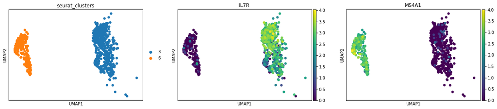

```python
#
sc.pl.umap(data, color=['seurat_clusters', 'IL7R','MS4A1'], use_raw=False)
```

### **1.2 reading data from R singlecellexperiment**

```python
data = myh5.input.read_h5(file = './sce_r.h5')
```

```python
data
```

```
AnnData object with n_obs × n_vars = 806 × 19037
    obs: 'orig.ident', 'nCount_RNA', 'nFeature_RNA', 'percent.mt', 'RNA_snn_res.0.4', 'seurat_clusters'
    var: 'vst.mean', 'vst.variance', 'vst.variance.expected', 'vst.variance.standardized', 'vst.variable'
    obsm: 'X_pca', 'X_tsne'
```

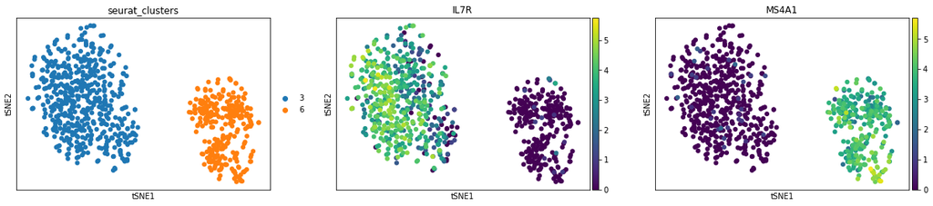

```python
# plot
sc.pl.tsne(data, color=['seurat_clusters','IL7R','MS4A1'], use_raw=False)
```

## **2. reading data from Python scanpy and save the h5 file**

### **2.1 read data from h5ad file**

[output not shown]

```python
# read the data from h5af file
adata = sc.read('./scanpy.h5ad')
```

```python
# adata.X is the scale data
adata
```

```
AnnData object with n_obs × n_vars = 278 × 2514
    obs: 'n_genes', 'n_genes_by_counts', 'total_counts', 'total_counts_mt', 'pct_counts_mt', 'leiden'
    var: 'gene_ids', 'feature_types', 'n_cells', 'mt', 'n_cells_by_counts', 'mean_counts', 'pct_dropout_by_counts', 'total_counts', 'highly_variable', 'means', 'dispersions', 'dispersions_norm', 'mean', 'std'
    uns: 'hvg', 'leiden', 'leiden_colors', 'neighbors', 'pca', 'umap'
    obsm: 'X_pca', 'X_umap'
    varm: 'PCs'
    obsp: 'connectivities', 'distances'
```

```python
# adata.X is the log data in the CSR format
adata.raw.X
```

```
<278x19037 sparse matrix of type '<class 'numpy.float32'>'
	with 661839 stored elements in Compressed Sparse Row format>
```

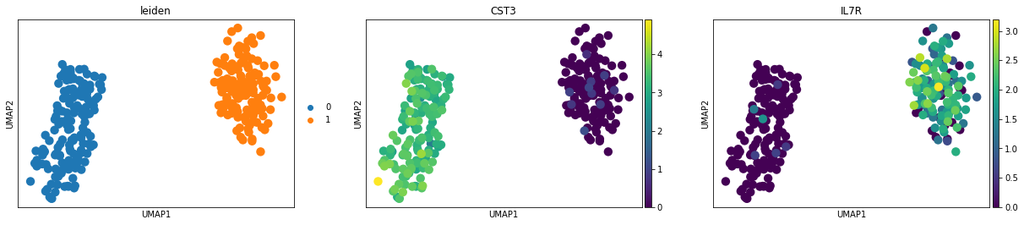

```python
sc.pl.umap(adata= adata, color = ['leiden','CST3','IL7R'])
```

### **2.2 save data into h5 file**

The scanpy data is saved to the h5 file which is can be read in R.Our software does not recommend saving **scale data** and gene expression matrix containing only HVGs.By default the `adata.raw.X` will be saved by set the `save_raw=True`

```python
# save the data
myh5.output.write_h5(adata = adata, file = './py_scanpy.h5')
```

If the our target adata is in `adata.X`, the `adata.X` will be saved by set the `save_raw=False`

```python
ad = anndata.AnnData(X=adata.raw.X, obs=adata.obs,var=adata.raw.var, obsm=adata.obsm)
```

```python
# save the data
myh5.output.write_h5(adata = ad, file='./py_scanpy_v1.h5', save_raw=False)
```

### **2.3 re-read the h5 file**

Note that the original position of the log normal data is changed because we do not save the scale, but the important information is completely retained and will not affect the downstream analysis.

```python
# read the
adata_r = myh5.input.read_h5( file = './py_scanpy.h5')
```

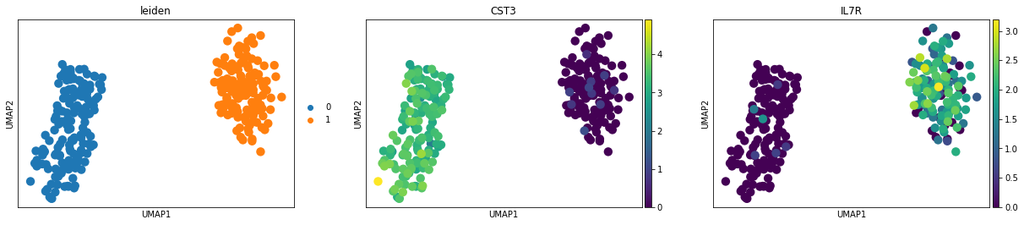

```python
# check the coordinate, cell annotation, cell annotation and log-normal data
sc.pl.umap(adata= adata_r, color = ['leiden','CST3','IL7R'])
```

### **2.4 Turn to the RIOH5 tutorial**

Let's go to the [RIOH5](https://jiekailab.github.io/scIO/sc_data_IO_r.html) tutorial to see more details.

```python
from sinfo import sinfo
sinfo()
```

```
-----
PyIOH5      NA
anndata     0.7.4
numpy       1.19.3
scanpy      1.6.0
scipy       1.5.3
sinfo       0.3.1
-----
IPython             7.8.0
jupyter_client      5.3.4
jupyter_core        4.6.0
jupyterlab          1.1.4
notebook            6.0.1
-----
Python 3.7.3 (default, Mar 27 2019, 22:11:17) [GCC 7.3.0]
Linux-3.10.0-693.el7.x86_64-x86_64-with-centos-7.4.1708-Core
56 logical CPU cores, x86_64
-----
Session information updated at 2021-01-18 20:57
```